# Assessment of Racial and Ethnic Differences in Oxygen Supplementation

Qualitatively replicate the results of the [Assessment of Racial and Ethnic Differences in Oxygen Supplementation Among Patients in the Intensive Care Unit](https://jamanetwork.com/journals/jamainternalmedicine/fullarticle/2794196) study, including:

- differences in the oxygen delivery rates between the racial groups (non-parametric Wilcoxon test of the difference of means of the oxygen delivery rates)
- differences in SpO2 for a given hemoglobin oxygen saturation (So2) between races and ethnicities when controlling for gender (simplified regression model 1)

## Data processing (_data/ptl_mimic-2.2)

Initialize

```r
library(lubridate)
library(MLmetrics)
library(dplyr)
library(ggplot2)
source('R/functions.R')
```

Load subject and observation data (o2 flow, spo2 and so2) from dataset: “_data/ptl_mimic-2.2”.

```r
subject_df <- load_subject(file.path(params$dataset, 'subject.csv'))
reading_o2_flow_df <- load_reading(file.path(params$dataset, 'reading_o2_flow.csv'))
reading_so2_df <- load_reading(file.path(params$dataset,'reading_so2.csv'))
reading_spo2_df <- load_reading(file.path(params$dataset,'reading_spo2.csv'))
```

Compute the average values of observations flow for each subject.

```r
avg_o2_flow_df <- reading_o2_flow_df %>%
  arrange(subject_id, chart_time) %>%
  group_by(subject_id) %>%
  group_modify(~ data.frame(o2_flow = avg_reading(.x$chart_time, .x$o2_flow))) %>%
  filter(o2_flow < 20)  %>% filter(o2_flow > 0) %>%# remove outliers
  ungroup()

avg_so2_df <- reading_so2_df %>%
  filter(so2 > 70) %>%
  arrange(subject_id, chart_time, so2) %>%
  group_by(subject_id) %>%
  group_modify(~ data.frame(so2 = avg_reading(.x$chart_time, .x$so2))) %>%
  ungroup()

avg_spo2_df <- reading_spo2_df %>%
  arrange(subject_id, chart_time) %>%
  group_by(subject_id) %>%
  group_modify(~ data.frame(spo2 = avg_reading(.x$chart_time, .x$spo2))) %>%
  ungroup()
```

## Compare oxygen delivery rates by race/ethnicity

Analysis of the differences in oxygen delivery rates by race and ethnicity.

See “Result/Factors Associated With Oxygen Delivery Rates” and Figure 2b in the original paper.

Assumption/Differences:

- For Wilcoxon test we assume “greater” alternative hypothesis, i.e. the O2 flow is higher for WHITE patients. This is not explicitly stated in the original paper, but it is a reasonable assumption given the context.

Join with the subject data with the average o2 flow data, and summarize the cohort.

```r
subject_with_o2_flow_df <- subject_df %>% inner_join(avg_o2_flow_df, by='subject_id')
summary(subject_with_o2_flow_df)
```

```
##   subject_id        gender    race_category     o2_flow
##  Length:6920        F:2406   WHITE   :6017   Min.   :1.000
##  Class :character   M:4514   ASIAN   : 196   1st Qu.:2.365
##  Mode  :character            BLACK   : 457   Median :3.016
##                              HISPANIC: 250   Mean   :3.228
##                                              3rd Qu.:4.000
##                                              Max.   :6.000
```

Compare the differences in oxygen delivery rates by race/ethnicity.

```r
iqr_df <- subject_with_o2_flow_df %>%
  group_by(race_category) %>%
  summarize(
    count = n(),
    mean = mean(o2_flow),
    Q1 = quantile(o2_flow, .25),
    median = quantile(o2_flow, .5),
    Q3 = quantile(o2_flow, .75),
    IQR = IQR(o2_flow, na.rm = TRUE)
  )
iqr_df
```

| race_category | count | mean | Q1 | median | Q3 | IQR |
| --- | --- | --- | --- | --- | --- | --- |
| WHITE | 6017 | 3.258294 | 2.404762 | 3.068966 | 4.000000 | 1.595238 |
| ASIAN | 196 | 2.870019 | 2.000000 | 2.658013 | 3.500000 | 1.500000 |
| BLACK | 457 | 3.054214 | 2.166667 | 2.882050 | 3.758852 | 1.592185 |
| HISPANIC | 250 | 3.090248 | 2.252016 | 2.881692 | 3.859307 | 1.607291 |

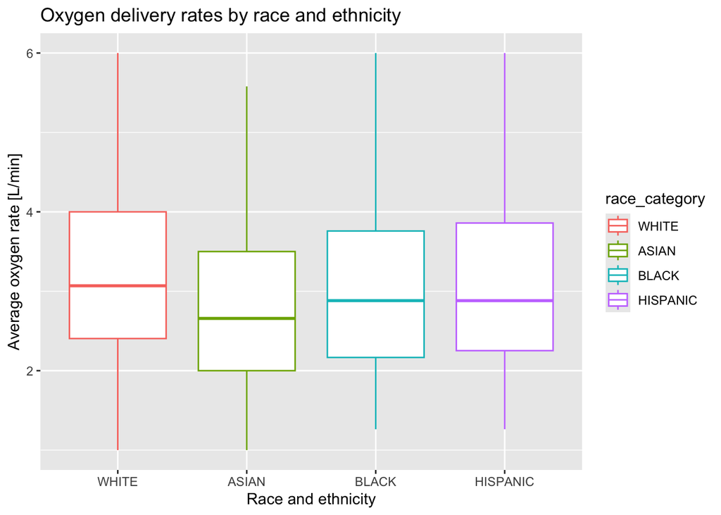

```r
(ggplot(subject_with_o2_flow_df, aes(x=race_category, y=o2_flow, colour = race_category))
  + geom_boxplot()
  + labs(x = "Race and ethnicity", y = "Average oxygen rate [L/min]", title = "Oxygen delivery rates by race and ethnicity")
)
```

### Test for differences in mean O2 flow by race/ethnicity

Test for differences in mean O2 flow against ‘WHITE’ using unpaired non-parametric Wilcoxon test.

#### Black vs White

```r
wc_white_black <- wilcox.test(o2_flow ~ race_category, alternative = 'greater',
                       data = subject_with_o2_flow_df %>% filter(race_category %in% c('WHITE', 'BLACK') ))
wc_white_black
```

```
##
##  Wilcoxon rank sum test with continuity correction
##
## data:  o2_flow by race_category
## W = 1547631, p-value = 3.563e-06
## alternative hypothesis: true location shift is greater than 0
```

#### Asian vs White

```r
wc_white_asian <- wilcox.test(o2_flow ~ race_category, alternative = 'greater',
                       data = subject_with_o2_flow_df %>% filter(race_category %in% c('WHITE', 'ASIAN') ))
wc_white_asian
```

```
##
##  Wilcoxon rank sum test with continuity correction
##
## data:  o2_flow by race_category
## W = 725470, p-value = 1.883e-08
## alternative hypothesis: true location shift is greater than 0
```

#### Hispanic vs White

```r
wc_white_hispanic <- wilcox.test(o2_flow ~ race_category, alternative = 'greater',
                       data = subject_with_o2_flow_df %>% filter(race_category %in% c('WHITE', 'HISPANIC') ))
wc_white_hispanic
```

```
##
##  Wilcoxon rank sum test with continuity correction
##
## data:  o2_flow by race_category
## W = 829292, p-value = 0.002926
## alternative hypothesis: true location shift is greater than 0
```

### Discussion

Like on the original study, we found that the average oxygen flow rate was higher for white patients compared to non white patients. The difference was statistically significant for black (p = 3.56276^{-6}), asian (p = 1.882805^{-8}) and hispanic (p = 0.0029265) patients.

## Compare Spo2 ~ So2 by race/ethnicity

Multivariable linear regression was performed to determine the association between blood hemoglobin oxygen saturation and SpO2.

Specifically, models with race and ethnicity as a covariate were developed to show associations, including SpO2 as a function of criterion standard hemoglobin oxygen saturation to confirm different device performance between races and ethnicities.

See “Pulse Oximetry and Hemoglobin Oxygen Saturation by Race and Ethnicity” and Figure 2A in the original paper.

Join with the subject data with the average Spo2 and So2 data, and summarize the cohort.

```r
subject_with_so2_df <- subject_df %>% inner_join(avg_so2_df, by='subject_id') %>% inner_join(avg_spo2_df, by='subject_id')
summary(subject_with_so2_df)
```

```
##   subject_id        gender    race_category       so2              spo2
##  Length:6901        F:2399   WHITE   :6002   Min.   : 71.00   Min.   : 77.45
##  Class :character   M:4502   ASIAN   : 195   1st Qu.: 95.81   1st Qu.: 95.82
##  Mode  :character            BLACK   : 454   Median : 97.00   Median : 96.82
##                              HISPANIC: 250   Mean   : 96.46   Mean   : 96.72
##                                              3rd Qu.: 98.00   3rd Qu.: 97.79
##                                              Max.   :100.00   Max.   :100.00
```

Differences in SpO2 for a given hemoglobin oxygen saturation between races and ethnicities.

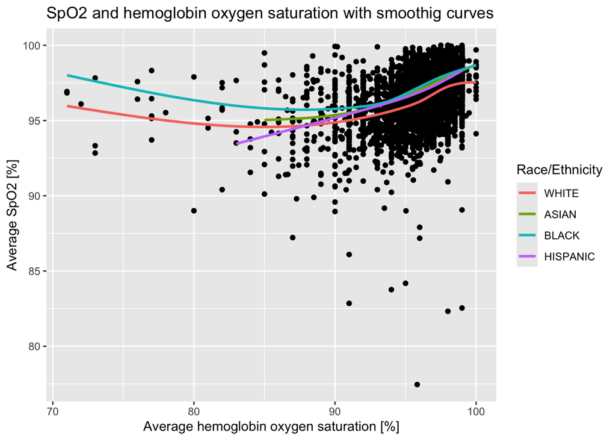

```r
print(
  ggplot(subject_with_so2_df, aes(x=so2, y=spo2))
    + geom_point()
    + geom_smooth(aes(colour = race_category), se = FALSE, method='gam')
    + labs(x = "Average hemoglobin oxygen saturation [%]",
           y = "Average SpO2 [%]",
           color="Race/Ethnicity",
           title = "SpO2 and hemoglobin oxygen saturation with smoothig curves")
)
```

### Linear model 1 (simplified)

Multivariate linear model to test the association between SpO2 and So2, controlling for race/ethnicity and gender.

```r
spo2_lm <-lm(spo2 ~  so2 + race_category + gender, data = subject_with_so2_df)
spo2_lm_summary <- summary(spo2_lm)
print(spo2_lm_summary)
```

```
##
## Call:
## lm(formula = spo2 ~ so2 + race_category + gender, data = subject_with_so2_df)
##
## Residuals:
##      Min       1Q   Median       3Q      Max
## -18.9985  -0.8454   0.0581   0.9055   7.3795
##
## Coefficients:
##                        Estimate Std. Error t value Pr(>|t|)
## (Intercept)           71.192145   0.705548 100.903  < 2e-16 ***
## so2                    0.263775   0.007308  36.093  < 2e-16 ***
## race_categoryASIAN     0.732199   0.104762   6.989 3.02e-12 ***
## race_categoryBLACK     0.872089   0.070401  12.387  < 2e-16 ***
## race_categoryHISPANIC  0.542564   0.092938   5.838 5.53e-09 ***
## genderM               -0.016686   0.036520  -0.457    0.648
## ---
## Signif. codes:  0 '***' 0.001 '**' 0.01 '*' 0.05 '.' 0.1 ' ' 1
##
## Residual standard error: 1.44 on 6895 degrees of freedom
## Multiple R-squared:  0.1769, Adjusted R-squared:  0.1763
## F-statistic: 296.5 on 5 and 6895 DF,  p-value: < 2.2e-16
```

```r
coef <- as.list(coef(spo2_lm))
pvalues <- as.list(spo2_lm_summary$coefficients[, "Pr(>|t|)"])
```